# Cars Regression Model

# Results

## Summary after Variable Transformation

Now we will begin to analyze the data. The first thing we do is get a new summary of the data. Here we see that there are more automatic transmission cars than thear are manual ones.

```r
summary(mtcars)
```

```
##       mpg        cyl         disp             hp             drat
##  Min.   :10.40   4:11   Min.   : 71.1   Min.   : 52.0   Min.   :2.760
##  1st Qu.:15.43   6: 7   1st Qu.:120.8   1st Qu.: 96.5   1st Qu.:3.080
##  Median :19.20   8:14   Median :196.3   Median :123.0   Median :3.695
##  Mean   :20.09          Mean   :230.7   Mean   :146.7   Mean   :3.597
##  3rd Qu.:22.80          3rd Qu.:326.0   3rd Qu.:180.0   3rd Qu.:3.920
##  Max.   :33.90          Max.   :472.0   Max.   :335.0   Max.   :4.930
##        wt             qsec       vs     am     gear   carb
##  Min.   :1.513   Min.   :14.50   0:18   0:19   3:15   1: 7
##  1st Qu.:2.581   1st Qu.:16.89   1:14   1:13   4:12   2:10
##  Median :3.325   Median :17.71                 5: 5   3: 3
##  Mean   :3.217   Mean   :17.85                        4:10
##  3rd Qu.:3.610   3rd Qu.:18.90                        6: 1
##  Max.   :5.424   Max.   :22.90                        8: 1
```

## Graphing The Data

Here we will graph the data to get a better sense of how the am (Transmission) variable affects mpg. First we will look at a distribution of the mpg variable. Then we will look at the spread broken down by transmission. When looking at the spread of the distribution we see that most of the data is centered around 13-23 mpg. We also see in the graph of mpg broken down by transmission that manual transmission cars get better gas mileage.

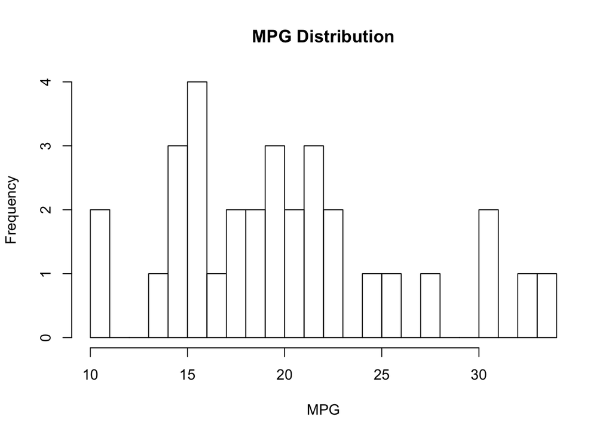

```r
hist(mtcars$mpg, xlab = "MPG", main = "MPG Distribution", breaks = 30)
```

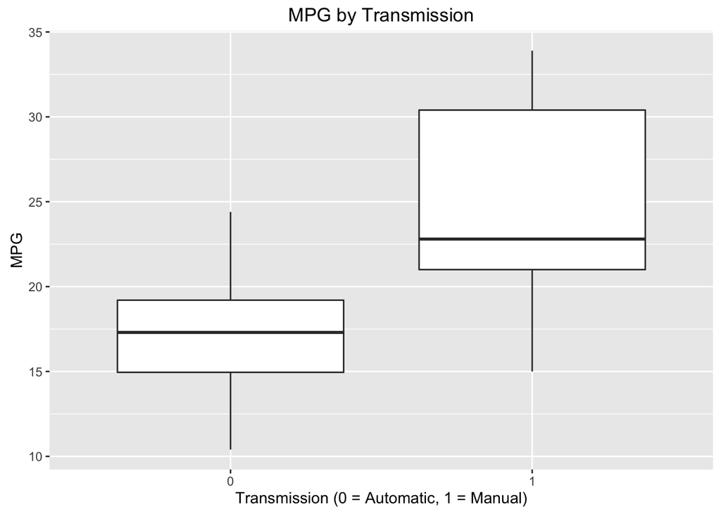

```r
ggplot(mtcars, aes(x = factor(am), y = mpg)) +
  geom_boxplot() +
  labs(x = "Transmission (0 = Automatic, 1 = Manual)",
       y = "MPG", title = "MPG by Transmission")
```

## Quantifying The Median

We see that the median mpg in a manual transmission car is greater than the median mpg in an automatic transmission car. We will calculate the median mpg’s for the cars to see the numbers

```r
median_summary <- mtcars %>%
  group_by(am) %>%
  summarize(median_mpg = median(mpg))
median_summary
```

```
## Source: local data frame [2 x 2]
##
##       am median_mpg
##   (fctr)      (dbl)
## 1      0       17.3
## 2      1       22.8
```

## Regression Models

We will fit a few regression models on the data to see if there is any change in mpg based on transmission. Also we will look at how transmission affects mpg when considering the other variables.

### Model 1: MPG by Transmission

```r
fit_am <- lm(mpg ~ am, mtcars)
summary(fit_am)
```

```
##
## Call:
## lm(formula = mpg ~ am, data = mtcars)
##
## Residuals:
##     Min      1Q  Median      3Q     Max
## -9.3923 -3.0923 -0.2974  3.2439  9.5077
##
## Coefficients:
##             Estimate Std. Error t value Pr(>|t|)
## (Intercept)   17.147      1.125  15.247 1.13e-15 ***
## am1            7.245      1.764   4.106 0.000285 ***
## ---
## Signif. codes:  0 '***' 0.001 '**' 0.01 '*' 0.05 '.' 0.1 ' ' 1
##
## Residual standard error: 4.902 on 30 degrees of freedom
## Multiple R-squared:  0.3598, Adjusted R-squared:  0.3385
## F-statistic: 16.86 on 1 and 30 DF,  p-value: 0.000285
```

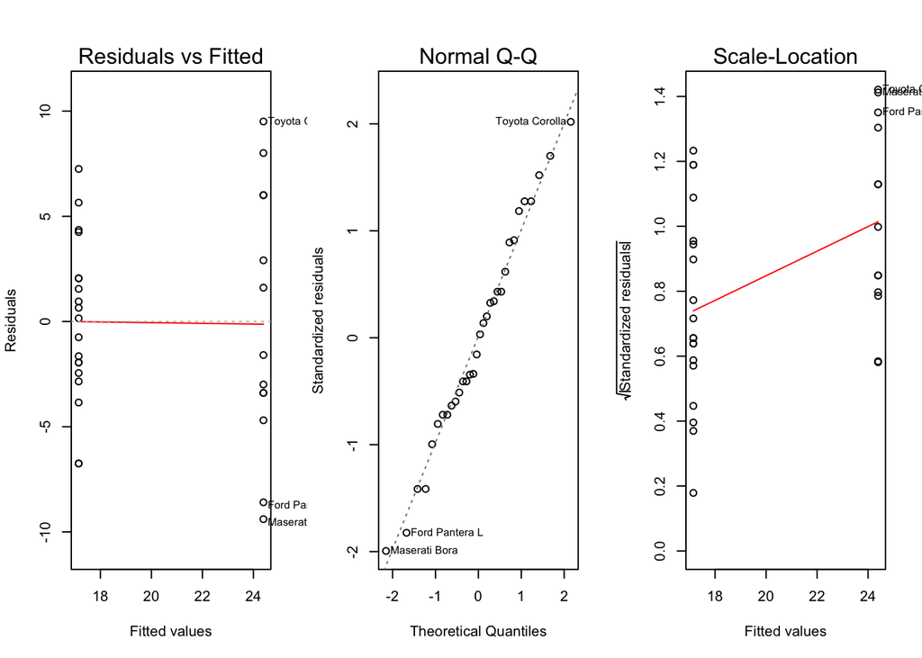

```r
par(mfrow = c(1,3))
plot(fit_am, which = 1)
plot(fit_am, which = 2)
plot(fit_am, which = 3)
```

From this model we see that the automatic transmission will have a mean of about 17.15 mpg. When interpretting the model we see the (Intercept) estimate as the first level of the factor variable am. The first level of this variable is automatic transmission. The difference in means between automatic transmission and manual transmission in our model is about 7.25 mpg. Therefore manual tranmsission cars have a mean of about 24.40 mpg. The *** next to the estimates indicate that our estimates are significant to the 0.001 confidence interval. The Resisual Standard Error is about 4.90 which means that difference between actual mpg and predicted mpg on the model differ by about 4.90 percentage points. The R-squared is 0.3598, which says that about 35.98% of the variability in mpg is explained by this model.

Although this model shows a relationship between mpg and transmission, there are other factors to consider when trying to determine this relationship. Each variable that is added to the model will change the coefficient for transmission. Variables correlated with transmission will have more of an effect on its coefficient than uncorrelated variables, but all added variables will have an effect. So we construct a new model containing all variables. This model will have the best fit when determining predicted mpg based on the data.

### Model 2: MPG by All Variables

```r
fit_all <- lm(mpg ~ ., mtcars)
summary(fit_all)
```

```
##
## Call:
## lm(formula = mpg ~ ., data = mtcars)
##
## Residuals:
##     Min      1Q  Median      3Q     Max
## -3.5087 -1.3584 -0.0948  0.7745  4.6251
##
## Coefficients:
##             Estimate Std. Error t value Pr(>|t|)
## (Intercept) 23.87913   20.06582   1.190   0.2525
## cyl6        -2.64870    3.04089  -0.871   0.3975
## cyl8        -0.33616    7.15954  -0.047   0.9632
## disp         0.03555    0.03190   1.114   0.2827
## hp          -0.07051    0.03943  -1.788   0.0939 .
## drat         1.18283    2.48348   0.476   0.6407
## wt          -4.52978    2.53875  -1.784   0.0946 .
## qsec         0.36784    0.93540   0.393   0.6997
## vs1          1.93085    2.87126   0.672   0.5115
## am1          1.21212    3.21355   0.377   0.7113
## gear4        1.11435    3.79952   0.293   0.7733
## gear5        2.52840    3.73636   0.677   0.5089
## carb2       -0.97935    2.31797  -0.423   0.6787
## carb3        2.99964    4.29355   0.699   0.4955
## carb4        1.09142    4.44962   0.245   0.8096
## carb6        4.47757    6.38406   0.701   0.4938
## carb8        7.25041    8.36057   0.867   0.3995
## ---
## Signif. codes:  0 '***' 0.001 '**' 0.01 '*' 0.05 '.' 0.1 ' ' 1
##
## Residual standard error: 2.833 on 15 degrees of freedom
## Multiple R-squared:  0.8931, Adjusted R-squared:  0.779
## F-statistic:  7.83 on 16 and 15 DF,  p-value: 0.000124
```

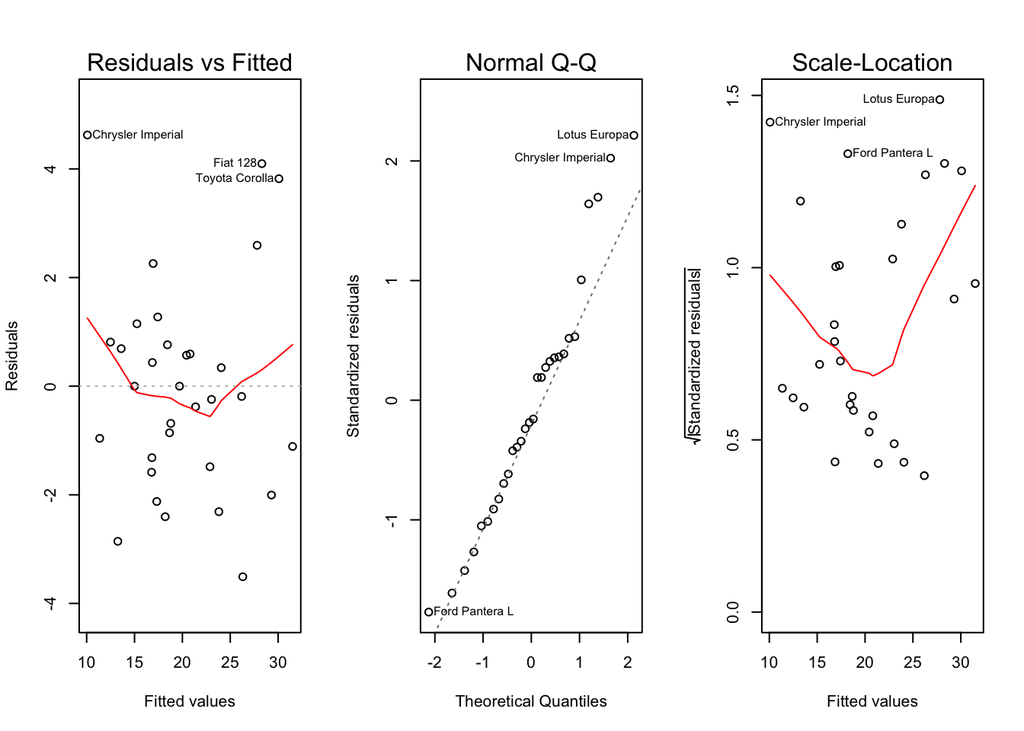

```r
par(mfrow = c(1,3))
plot(fit_all, which = 1)
plot(fit_all, which = 2)
plot(fit_all, which = 3)
```

```r
anova(fit_am, fit_all)
```

```
## Analysis of Variance Table
##
## Model 1: mpg ~ am
## Model 2: mpg ~ cyl + disp + hp + drat + wt + qsec + vs + am + gear + carb
##   Res.Df   RSS Df Sum of Sq      F   Pr(>F)
## 1     30 720.9
## 2     15 120.4 15    600.49 4.9874 0.001759 **
## ---
## Signif. codes:  0 '***' 0.001 '**' 0.01 '*' 0.05 '.' 0.1 ' ' 1
```

Residual Sum of Sqares (RSS) decreases in the models from 720.90 to 120.4. Therefore there is less deviance in Model 2 than there is in Model 1. The ** at the right of the table indicates that the null hypothesis is rejected at the level of 0.01. So at least one of the additional regressors is significant. This rejection is based on applying Pr(>F) to the F statistic 4.99. All of this is evidence that the second model is a better predictor than the first model is.